# Island analysis using various genomics datasets

Kaelan (1028-02098-001-001)

December 13, 2022

# 1. Introduction

The goal of this analysis is to use island analysis to look at how chromatin accessibility, as well as MNase and histone modifications, vary across different genomic loci. Here, we define islands based on motifs that are proximal to one another (in this case, 200 bp, for nucleosome-range distances). We do this is order to see what combinations of motifs generate the highest and lowest levels of acessibility, nucleosome occupancy, and active histone modifications. We are using BPNet-mapped TF binding motifs in this analysis. Note that this analysis will encompass Figure 4 and its supplemental.

# 2. Computational Setup

```r
#Standard packages
library(rtracklayer) ; library(GenomicRanges); library(magrittr) ; library(Biostrings)
library(ggplot2) ; library(reshape2); library(plyranges); library(Rsamtools); library(ggpubr)
library(dplyr); library(data.table); library(patchwork); library(readr); library(testit); library(cowplot)

#KNITR Options
setwd("/l/Zeitlinger/ZeitlingerLab/Manuscripts/Zelda_and_Nucleosomes/Analysis/analysis/")
options(knitr.figure_dir="figures/13_island_analysis/", java.parameters = "- Xmx6g")

#Lab sources
source("scripts/r/granges_common.r")
source("scripts/r/metapeak_common.r")
source("scripts/r/knitr_common.r")
source("scripts/r/caching.r")
source("scripts/r/metapeak_functions.r")

#Specific sources
library(ggseqlogo)
library(BSgenome.Dmelanogaster.UCSC.dm6)
library(rhdf5)
source("scripts/r/motif_functions.r")

#Pre-existing variables
modisco_dir <- 'bpnet/modisco/fold1/'
tasks <- c('Zld','Dl','Twi','Bcd','Cad','GAF')
threads <- 5
bsgenome<-BSgenome.Dmelanogaster.UCSC.dm6
```

# 3. Import relevant data

```r
# BPNet-identified motifs

motifs.gr <- readr::read_tsv('/l/Zeitlinger/ZeitlingerLab/Manuscripts/Zelda_and_Nucleosomes/Analysis/analysis/tsv/mapped_motifs/all_instances_curated_1based.tsv.gz') %>%
  GenomicRanges::makeGRangesFromDataFrame(keep.extra.columns = T, starts.in.df.are.0based = F)

## How many motifs do we have?

motifs.gr$pattern_name %>% table()
```

```
## .
##   Bcd   Cad    Dl   GAF   Twi   Zld
## 17344 13491  1965  7429 23825  5264
```

```r
# Coverage files

atac.list <- list(orer_1to15 = '/l/Zeitlinger/ZeitlingerLab/Manuscripts/Zelda_and_Nucleosomes/Analysis/data/bw/dm6/atac/combined/orer_1to15_atac_combined_normalized.bw',
                  orer_15to2 = '/l/Zeitlinger/ZeitlingerLab/Manuscripts/Zelda_and_Nucleosomes/Analysis/data/bw/dm6/atac/combined/orer_15to2_atac_combined_normalized.bw',
                  orer_2to25 = '/l/Zeitlinger/ZeitlingerLab/Manuscripts/Zelda_and_Nucleosomes/Analysis/data/bw/dm6/atac/combined/orer_2to25_atac_combined_normalized.bw',
                  orer_25to3 = '/l/Zeitlinger/ZeitlingerLab/Manuscripts/Zelda_and_Nucleosomes/Analysis/data/bw/dm6/atac/combined/orer_25to3_atac_combined_normalized.bw')
mnase.bw <- '/l/Zeitlinger/ZeitlingerLab/Manuscripts/Zelda_and_Nucleosomes/Analysis/data/bw/dm6/mnase/combined/orer_mbt_100u_mnase_combined_normalized.bw'
h3k27ac.bw <- '/l/Zeitlinger/ZeitlingerLab/Manuscripts/Zelda_and_Nucleosomes/Analysis/data/bw/dm6/seq/combined/orer_h3k27ac_mbt_seq_combined_log2_normalized.bw'
h3k4me1.bw <- '/l/Zeitlinger/ZeitlingerLab/Manuscripts/Zelda_and_Nucleosomes/Analysis/data/bw/dm6/seq/combined/orer_h3k4me1_mbt_seq_combined_log2_normalized.bw'
```

# 4. Define islands

## 4.1. Filter to take only bound motifs

```r
bound_motifs.gr <- lapply(motifs.gr$pattern_name %>% unique, function(x){
  gr<-motifs.gr %>%
    plyranges::filter(pattern_name == x) %>%
    subsetByOverlaps(.,
                     rtracklayer::import(paste0('/l/Zeitlinger/ZeitlingerLab/Manuscripts/Zelda_and_Nucleosomes/Analysis/data/narrowpeak/nexus_orer_mbt_', tolower(x), '_peaks.narrowpeak')) %>%
                       resize(500, 'center'),
                     ignore.strand = T)
  return(gr)
}) %>% GRangesList %>% unlist

bound_motifs.gr$pattern_name %>% table
```

```
## .
##   Bcd   Cad    Dl   GAF   Twi   Zld
## 14375 11646  1770  7061 21173  4601
```

## 4.2. Generate islands

```r
##look at regions with many motifs
islands_number.gr<-bound_motifs.gr %>% resize(200, "center")
islands_number.gr <- reduce(islands_number.gr, ignore.strand = T)
islands_number.gr$island_id<-1:length(islands_number.gr)

##assign motifs to an island
number_ov<-findOverlaps(bound_motifs.gr, islands_number.gr, ignore.strand = T)
instances_number_ov.gr<-bound_motifs.gr[number_ov@from]
instances_number_ov.gr$island_id<-islands_number.gr[number_ov@to]$island_id

##Find number of motifs across each island
instances_number_ov.gr$island_id %>% table %>% table
```

```
## .
##     1     2     3     4     5     6     7     8     9    10    11    12    13
## 23438  9151  3398  1164   434   163    64    30    11     3     3     1     2
```

```r
##Find all motif combinations across each island (counted)

islands_vs_motifs_counted.df<-mclapply(unique(instances_number_ov.gr$pattern_name), function(x){
  vec<-rep(NA, length(islands_number.gr))
  instance_ov.gr<-subset(instances_number_ov.gr, x == pattern_name)
  instance_to_island_ids<-instance_ov.gr$island_id %>% table
  vec[as.integer(names(instance_to_island_ids))]<-paste0(x, "(", as.character(instance_to_island_ids), ")")
  return(vec)
}, mc.cores = 11) %>% as.data.frame
colnames(islands_vs_motifs_counted.df)<-unique(instances_number_ov.gr$pattern_name)
rownames(islands_vs_motifs_counted.df)<-1:length(islands_number.gr)

##Extract island combinations and summarize
island_combos_number.vec<-apply(islands_vs_motifs_counted.df, 1, function(x){
  vec<-x[!is.na(x)]
  str<-paste0(vec, collapse = "/")
  return(str)
})
island_combos_number.freq.df<-table(island_combos_number.vec) %>% as.data.frame
colnames(island_combos_number.freq.df)<-c("Motif combo", "freq")
island_combos_number.freq.df<-island_combos_number.freq.df[order(island_combos_number.freq.df$freq, decreasing = T),]

## Map combinations back to islands
islands_vs_motifs_counted.df$motif_combination_class<-apply(islands_vs_motifs_counted.df, 1, function(x) paste0(as.character(x)[!is.na(x)], collapse = "_"))
islands_vs_motifs_counted.df$island_id<-1:nrow(islands_vs_motifs_counted.df)

## Map combinations back to motifs
instances_number_ov.gr<-dplyr::left_join(as.data.frame(instances_number_ov.gr), islands_vs_motifs_counted.df, by = "island_id") %>% makeGRangesFromDataFrame(df = ., keep.extra.columns = T, starts.in.df.are.0based = F)

## keep track of island information

island_names.df <- instances_number_ov.gr %>%
  GenomicRanges::sort(ignore.strand = T) %>%
  as.data.frame %>%
  dplyr::group_by(island_id) %>%
  dplyr::summarize(island_content = paste(unique(sort(pattern_name)), table(sort(pattern_name)), sep = '-', collapse = '_'),
                   island_content_ordered = paste(pattern_name, collapse = '_'),
                   island_content_unique = paste(unique(sort(pattern_name)), collapse = '_'),
                   island_count = length(pattern_name))

## Join island names with instances
motifs_with_island_info.df<-instances_number_ov.gr %>% as.data.frame %>%
  dplyr::left_join(., island_names.df, by = 'island_id')

## Join islands with island info

islands_with_all_info.gr <- island_names.df %>%
  dplyr::left_join(., islands_number.gr %>% as.data.frame) %>%
  makeGRangesFromDataFrame(keep.extra.columns = T, starts.in.df.are.0based = F)

# Now what we have is:

# 1) island coordinates that contain the genomic span for all motifs in that island, stored in:
head(islands_with_all_info.gr)
```

```
## GRanges object with 6 ranges and 5 metadata columns:
##       seqnames      ranges strand | island_id island_content
##          <Rle>   <IRanges>  <Rle> | <integer>    <character>
##   [1]    chr2L   5727-6004      * |         1    Cad-1_GAF-3
##   [2]    chr2L   7594-7828      * |         2          Bcd-2
##   [3]    chr2L   8638-9016      * |         3          Bcd-2
##   [4]    chr2L 17519-17718      * |         4          Twi-1
##   [5]    chr2L 20324-20523      * |         5          Twi-1
##   [6]    chr2L 26952-27285      * |         6          Zld-2
##       island_content_ordered island_content_unique island_count
##                  <character>           <character>    <integer>
##   [1]        GAF_Cad_GAF_GAF               Cad_GAF            4
##   [2]                Bcd_Bcd                   Bcd            2
##   [3]                Bcd_Bcd                   Bcd            2
##   [4]                    Twi                   Twi            1
##   [5]                    Twi                   Twi            1
##   [6]                Zld_Zld                   Zld            2
##   -------
##   seqinfo: 6 sequences from an unspecified genome; no seqlengths
```

```r
#2) motif instances that contain the island information as well, stored in:
head(instances_number_ov.gr)
```

```
## GRanges object with 6 ranges and 50 metadata columns:
##       seqnames            ranges strand |                pattern
##          <Rle>         <IRanges>  <Rle> |            <character>
##   [1]    chr2L 10001105-10001111      + | metacluster_0/patter..
##   [2]    chr2L 10001138-10001144      + | metacluster_0/patter..
##   [3]    chr2L 10001282-10001288      + | metacluster_0/patter..
##   [4]    chr2L   1000969-1000975      - | metacluster_0/patter..
##   [5]    chr2L   1001068-1001074      + | metacluster_0/patter..
##   [6]    chr2L   1001147-1001153      - | metacluster_0/patter..
##       contrib_weighted_p match_weighted_p pattern_start pattern_end
##                <numeric>        <numeric>     <numeric>   <numeric>
##   [1]          0.0819345         0.126699           445         452
##   [2]          0.7326139         0.551958           478         485
##   [3]          0.5531575         0.493605           622         629
##   [4]          0.9752198         0.166667           447         454
```

[output cut: 76 more lines]

```r
# View island widths and then calculate the distance between motifs in each island

width(islands_with_all_info.gr) %>% summary()
```

```
##    Min. 1st Qu.  Median    Mean 3rd Qu.    Max.
##   200.0   200.0   200.0   245.4   266.0   945.0
```

```r
motifs_in_islands_info.df <- motifs_with_island_info.df %>%
  dplyr::group_by(island_id) %>%
  dplyr::mutate(island_start_wrt_motif = min(start),
                island_end_wrt_motif = max(end),
                island_width_wrt_motifs = island_end_wrt_motif-island_start_wrt_motif)

motifs_in_islands_info.df$island_width_wrt_motifs %>% summary()
```

```
##    Min. 1st Qu.  Median    Mean 3rd Qu.    Max.
##    6.00    9.00   52.00   95.96  159.00  758.00
```

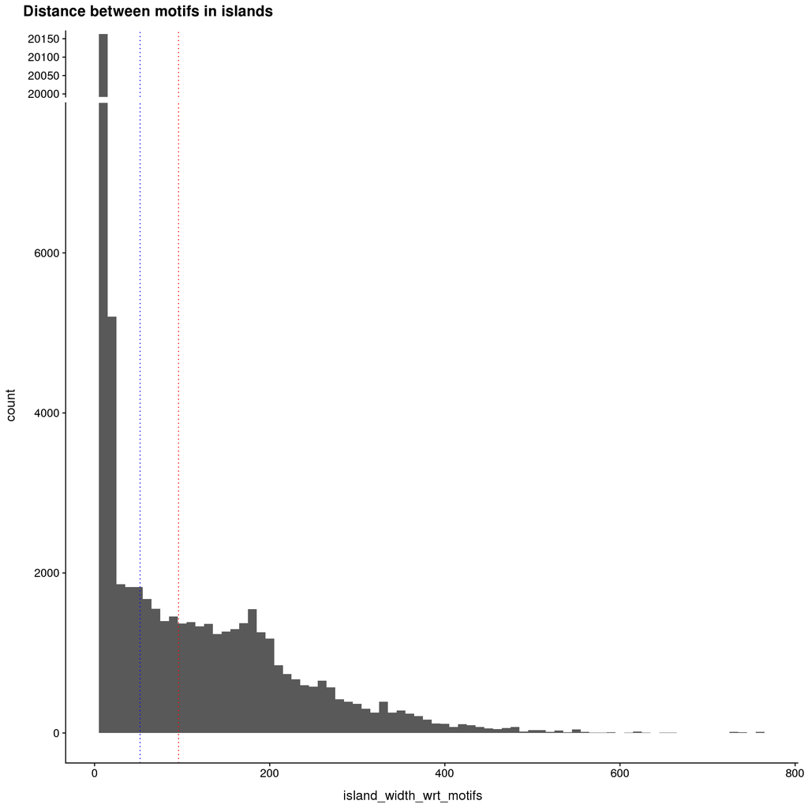

```r
library(ggbreak)

island.histogram <- ggplot(motifs_in_islands_info.df, aes(x = island_width_wrt_motifs))+
  geom_histogram(binwidth = 10)+
  geom_vline(xintercept = mean(motifs_in_islands_info.df$island_width_wrt_motifs), linetype = 'dotted', color = 'red') +
  geom_vline(xintercept = median(motifs_in_islands_info.df$island_width_wrt_motifs), linetype = 'dotted', color = 'blue') +
  ggtitle("Distance between motifs in islands") +
  scale_y_break(c(7500,20000), scales = .1) +
  theme_cowplot()
island.histogram
```

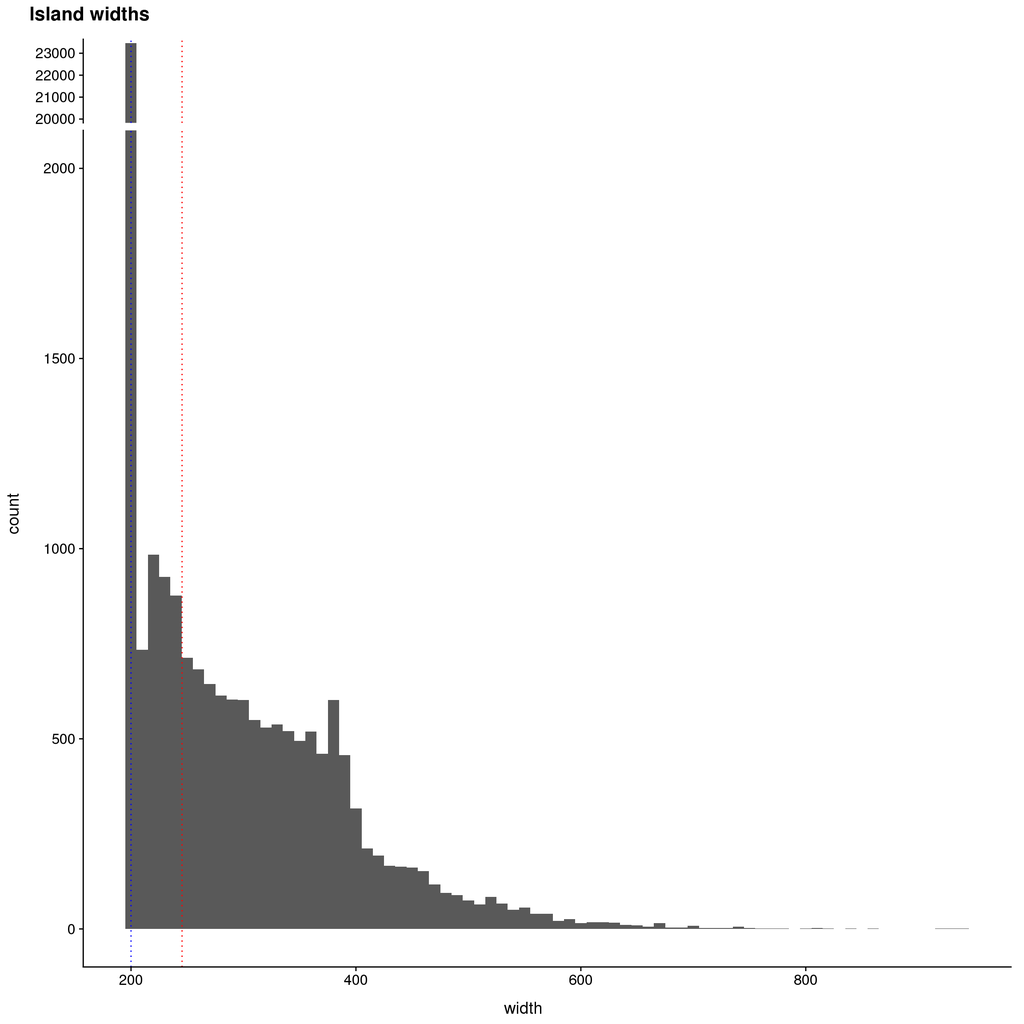

```r
island.length.histogram <- ggplot(as.data.frame(islands_with_all_info.gr), aes(x = width))+
  geom_histogram(binwidth = 10)+
  geom_vline(xintercept = mean(as.data.frame(islands_with_all_info.gr)$width), linetype = 'dotted', color = 'red') +
  geom_vline(xintercept = median(as.data.frame(islands_with_all_info.gr)$width), linetype = 'dotted', color = 'blue') +
  ggtitle("Island widths") +
  scale_y_break(c(2000,20000), scales = .1) +
  theme_cowplot()
island.length.histogram
```

```r
ggsave("islands_motifs_width_hist.pdf", plot = island.histogram, path = "figures/13_island_analysis", height = 6, width = 6)
ggsave("islands_motifs_width_hist.png", plot = island.histogram, path = "figures/13_island_analysis", height = 6, width = 6)
ggsave("islands_width_hist.pdf", plot = island.length.histogram, path = "figures/13_island_analysis", height = 6, width = 6)
ggsave("islands_width_hist.png", plot = island.length.histogram, path = "figures/13_island_analysis", height = 6, width = 6)
```

## 4.3. Remove low-observation islands

```r
islands_with_all_info.gr$island_content_unique %>% table %>% sort(decreasing = T) %>% head(n=20)
```

```
## .
##         Twi         Bcd         Cad         GAF         Zld     Bcd_Twi
##       11763        7036        6405        4136        1673         981
##     Cad_Twi     GAF_Twi          Dl     Bcd_Cad     Bcd_Zld     Twi_Zld
##         867         681         449         404         393         366
##     Cad_Zld     Cad_GAF      Dl_Twi     Bcd_GAF Bcd_Twi_Zld     GAF_Zld
##         268         244         235         214         161         141
## Bcd_Cad_Twi Bcd_Cad_Zld
##         135         107
```

```r
islands_with_all_info_filtered.gr <- as.data.frame(islands_with_all_info.gr) %>% group_by(island_content_unique) %>% filter(n()>= 30) %>% ungroup() %>% makeGRangesFromDataFrame(keep.extra.columns = TRUE)
```

## 4.4. Save these islands for use in other analyses

```r
saveRDS(islands_with_all_info_filtered.gr, file = "/l/Zeitlinger/ZeitlingerLab/Manuscripts/Zelda_and_Nucleosomes/Analysis/data/islands/zdtbcg_islands_w_all_info.RData")
```

## 4.5. UPSET plot for island counts

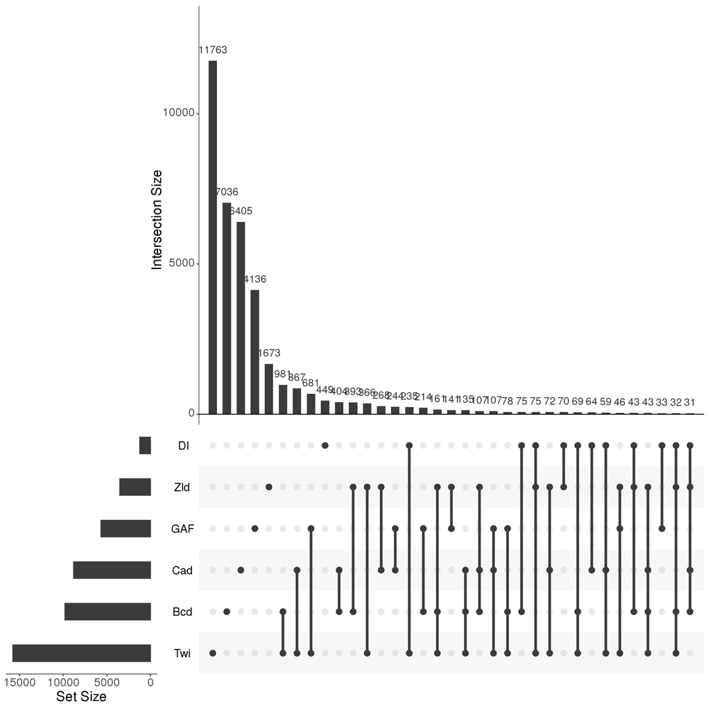

```r
library(UpSetR)

input <- c(Bcd = 7036,
  "Bcd&Cad" = 404,
  "Bcd&Cad&Dl&Zld" = 31,
  "Bcd&Cad&Twi" = 135,
  "Bcd&Cad&Twi&Zld" = 43,
  "Bcd&Cad&Zld" = 107,
  "Bcd&Dl" = 75,
  "Bcd&Dl&Twi" = 69,
  "Bcd&Dl&Twi&Zld" = 32,
  "Bcd&Dl&Zld" = 43,
  "Bcd&GAF" = 214,
  "Bcd&GAF&Twi" = 78,
  "Bcd&Twi" = 981,
  "Bcd&Twi&Zld" = 161,
  "Bcd&Zld" = 393,
  Cad = 6405,
  "Cad&Dl" = 64,
  "Cad&Dl&Twi" = 59,
  "Cad&GAF" = 244,
  "Cad&GAF&Twi" = 107,
  "Cad&Twi" = 867,
  "Cad&Twi&Zld" = 72,
  "Cad&Zld" = 268,
  Dl = 449,
  "Dl&GAF" = 33,
  "Dl&Twi" = 235,
  "Dl&Twi&Zld" = 75,
  "Dl&Zld" = 70,
  GAF = 4136,
  "GAF&Twi" = 681,
  "GAF&Twi&Zld" = 46,
  "GAF&Zld" = 141,
  Twi = 11763,
  "Twi&Zld" = 366,
  Zld = 1673
)

# Plot
upset(fromExpression(input),
      nintersects = 40,
      nsets = 6,
      order.by = "freq",
      decreasing = T,
      mb.ratio = c(0.6, 0.4),
      number.angles = 0,
      text.scale = 2,
      point.size = 3.5,
      line.size = 1.5
      )
```

# 5. Calculate chromatin accessibility, nucleosome occupancy, and histone modifications across islands

## 5.1. Calculate ATAC

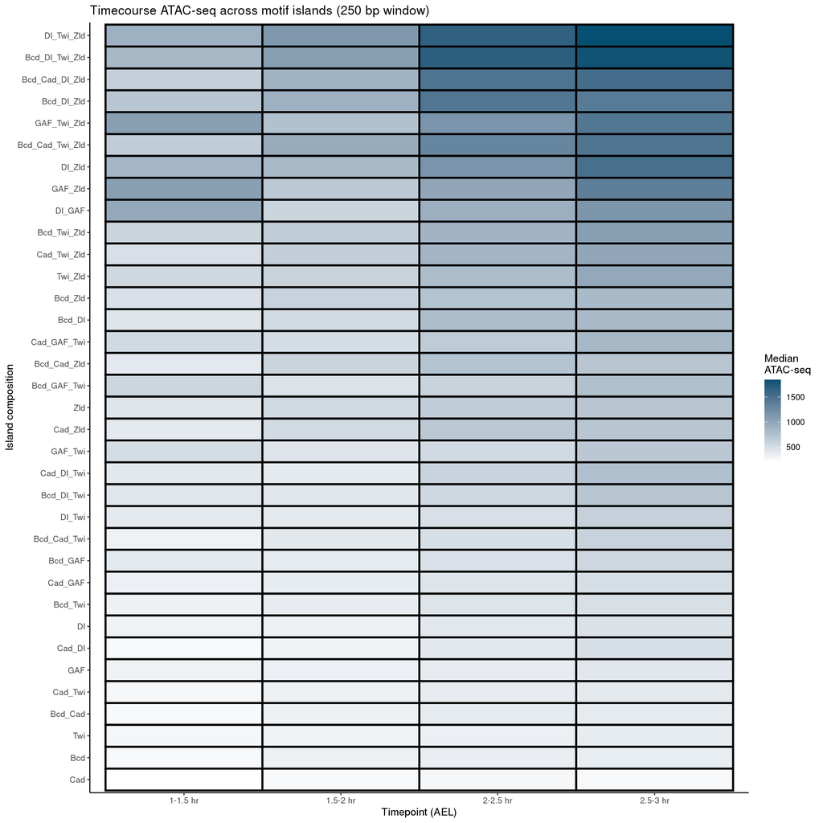

```r
atac_across_instances.df<-mclapply(names(atac.list), function(x){
  regionSums(islands_with_all_info_filtered.gr %>% resize(250, 'center'), atac.list[[x]])
}, mc.cores = 4) %>% as.data.frame()
names(atac_across_instances.df)<-names(atac.list)

islands_w_orer_atac.df<-cbind(islands_with_all_info_filtered.gr %>% as.data.frame, atac_across_instances.df) %>%
  dplyr::group_by(island_content_unique) %>%
  dplyr::summarize(`1 to 1.5hr wt` = median(`orer_1to15`),
                   `1.5 to 2hr wt` = median(`orer_15to2`),
                   `2 to 2.5hr wt` = median(`orer_2to25`),
                   `2.5 to 3hr wt` = median(`orer_25to3`)) %>%
  dplyr::mutate(contains_Zld = grepl(pattern = 'Zld', x = island_content_unique)) %>%
  as.data.table %>%
  melt.data.table(id.vars = c('island_content_unique','contains_Zld'), variable.name = 'timepoint', value.name = 'median_ATAC_signal')

# Order by accessibility at 2.5-3 hr

island_order_t4<-islands_w_orer_atac.df %>%
  dplyr::group_by(island_content_unique, timepoint) %>%
  dplyr::summarize(sum = sum(`median_ATAC_signal`)) %>%
  dplyr::arrange(desc(timepoint), sum) %>%
  .$island_content_unique %>% .[1:35]
islands_w_orer_atac.df$island_content_unique<-factor(islands_w_orer_atac.df$island_content_unique, levels = island_order_t4)

####### Order by row sum

island_order<-islands_w_orer_atac.df %>%
  dplyr::group_by(island_content_unique) %>%
  dplyr::summarize(sum = sum(`median_ATAC_signal`)) %>%
  dplyr::arrange(sum) %>%
  .$island_content_unique
islands_w_orer_atac.df$island_content_unique<-factor(islands_w_orer_atac.df$island_content_unique, levels = island_order)

######

atac_colors <- colorRampPalette(c("#0d0d0d", "#4dffdb"), bias=15)(32)

atac_plot <- ggplot(islands_w_orer_atac.df, aes(x = timepoint, y = island_content_unique, fill = `median_ATAC_signal`))+
    geom_tile(color = 'black', size = 1)+
    #scale_fill_gradientn(colors =  viridis(100))+
    theme_classic()+
    scale_x_discrete(name = "Timepoint (AEL)", labels = c("1-1.5 hr", "1.5-2 hr", "2-2.5 hr", "2.5-3 hr"))+
    ylab("Island composition")+
    ggtitle("Timecourse ATAC-seq across motif islands (250 bp window)")+
    #scale_fill_gradient2(low = "black", mid = "black", high = "steelblue1")+
    #scale_fill_gradientn(colors = atac_colors, name = 'Median\nATAC-seq', space = "Lab")
    scale_fill_gradientn(colors = c("white", "#055072"), name = 'Median\nATAC-seq', space = "Lab")
    #scale_fill_gradientn(colors = viridis(n=50), name = 'Median\nATAC-seq')
atac_plot
```

## 5.2. Calculate MNase

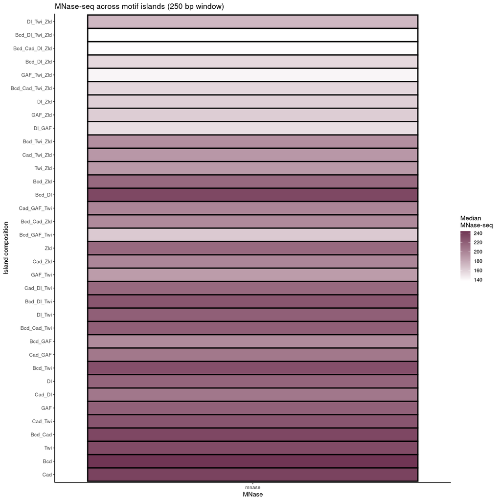

```r
mnase_across_instances.df <- regionSums(islands_with_all_info_filtered.gr %>% resize(250, 'center'), mnase.bw) %>% as.data.frame()
colnames(mnase_across_instances.df) <- "mnase"

islands_w_mnase.df<-cbind(islands_with_all_info_filtered.gr %>% as.data.frame, mnase_across_instances.df) %>%
  dplyr::group_by(island_content_unique) %>%
  dplyr::summarize(mnase = median(mnase)) %>%
  dplyr::mutate(contains_Zld = grepl(pattern = 'Zld', x = island_content_unique)) %>%
  as.data.table %>%
  melt.data.table(id.vars = c('island_content_unique','contains_Zld'), variable.name = 'timepoint', value.name = 'median_mnase_signal')

islands_w_mnase.df$island_content_unique<-factor(islands_w_mnase.df$island_content_unique, levels = island_order) #same order as ATAC timecourse heatmap

mnase_heatmap <- ggplot(islands_w_mnase.df, aes(x = timepoint, y = island_content_unique, fill = median_mnase_signal))+
    geom_tile(color = 'black', size = 1)+
    #scale_fill_gradientn(colors =  viridis(100))+
    theme_classic()+
    scale_x_discrete(name = "MNase")+
    ylab("Island composition")+
    ggtitle("MNase-seq across motif islands (250 bp window)")+
    scale_fill_gradientn(colors = c("white", "#703554"), name = 'Median\nMNase-seq')
    #scale_fill_gradientn(colors = magma(50), name = 'Median\nMNase-seq')
mnase_heatmap
```

## 5.3. Calculate H3K27ac

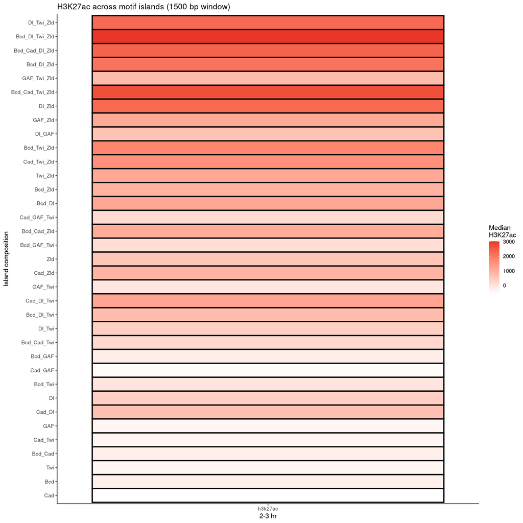

```r
k27_across_instances.df <- regionSums(islands_with_all_info_filtered.gr %>% resize(1500, 'center'), h3k27ac.bw) %>% as.data.frame()
colnames(k27_across_instances.df) <- "h3k27ac"

islands_w_k27.df<-cbind(islands_with_all_info_filtered.gr %>% as.data.frame, k27_across_instances.df) %>%
  dplyr::group_by(island_content_unique) %>%
  dplyr::summarize(h3k27ac = median(h3k27ac)) %>%
  dplyr::mutate(contains_Zld = grepl(pattern = 'Zld', x = island_content_unique)) %>%
  as.data.table %>%
  melt.data.table(id.vars = c('island_content_unique','contains_Zld'), variable.name = 'timepoint', value.name = 'median_h3k27ac_signal')

islands_w_k27.df$island_content_unique<-factor(islands_w_k27.df$island_content_unique, levels = island_order) #same order as ATAC timecourse heatmap

h3k27ac.island <- ggplot(islands_w_k27.df, aes(x = timepoint, y = island_content_unique, fill = median_h3k27ac_signal))+
    geom_tile(color = 'black', size = 1)+
    #scale_fill_gradientn(colors =  viridis(100))+
    theme_classic()+
    scale_x_discrete(name = "2-3 hr")+
    ylab("Island composition")+
    ggtitle("H3K27ac across motif islands (1500 bp window)")+
    scale_fill_gradientn(colors = c("white", "#EA3628"), name = 'Median\nH3K27ac')
    #scale_fill_gradientn(colors = magma(50), name = 'Median\nH3K27ac')
h3k27ac.island
```

## 5.4. Calculate H3K4me1

[figure not shown]

```r
k4me1_across_instances.df <- regionSums(islands_with_all_info_filtered.gr %>% resize(1500, 'center'), h3k4me1.bw) %>% as.data.frame()
colnames(k4me1_across_instances.df) <- "h3k4me1"

islands_w_k4me1.df<-cbind(islands_with_all_info_filtered.gr %>% as.data.frame, k4me1_across_instances.df) %>%
  dplyr::group_by(island_content_unique) %>%
  dplyr::summarize(h3k4me1 = median(h3k4me1)) %>%
  dplyr::mutate(contains_Zld = grepl(pattern = 'Zld', x = island_content_unique)) %>%
  as.data.table %>%
  melt.data.table(id.vars = c('island_content_unique','contains_Zld'), variable.name = 'timepoint', value.name = 'median_h3k4me1_signal')

islands_w_k4me1.df$island_content_unique<-factor(islands_w_k4me1.df$island_content_unique, levels = island_order) #same order as ATAC timecourse heatmap

k4me1_colors <- colorRampPalette(c("#0d0d0d", "#ffa31a"))(32)

h3k4me1.island <- ggplot(islands_w_k4me1.df, aes(x = timepoint, y = island_content_unique, fill = median_h3k4me1_signal))+
    geom_tile(color = 'black', size = 1)+
    #scale_fill_gradientn(colors =  viridis(100))+
    theme_classic()+
    scale_x_discrete(name = "2-3 hr")+
    ylab("Island composition")+
    ggtitle("H3K4me1 across motif islands (1000 bp window)")+
    scale_fill_gradientn(colors = c("white", "#E2911B"), name = 'Median\nH3K4me1')
    #scale_fill_gradientn(colors = magma(50), name = 'Median\nH3K4me1')
h3k4me1.island
```

## 5.5. Calculate overlap with known active enhancers

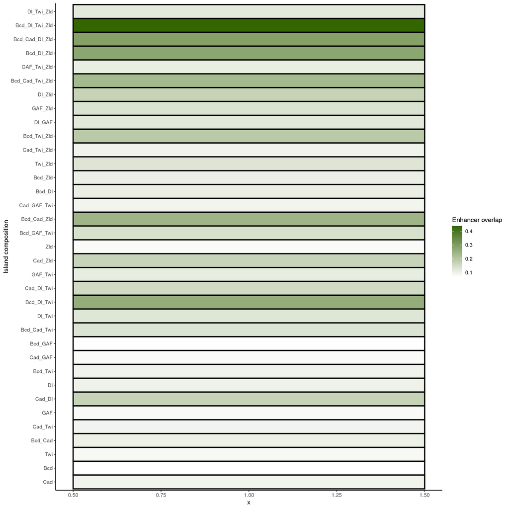

```r
# Import enhancers

cus_enhancers.gr <- rtracklayer::import('/l/Zeitlinger/ZeitlingerLab/Manuscripts/Zelda_and_Nucleosomes/Analysis/data/published/enhancers/cusanovich/cusanovich_dm6_enhancers.bed')

# Which islands have enhancers?

islands_with_all_info_filtered.gr$enhancer_name <- NA
ov <- findOverlaps(islands_with_all_info_filtered.gr, cus_enhancers.gr, ignore.strand = T)
islands_with_all_info_filtered.gr$enhancer_name[ov@from]<- cus_enhancers.gr$name[ov@to]
islands_with_all_info_filtered.gr$has_enhancer <- ifelse(is.na(islands_with_all_info_filtered.gr$enhancer_name), FALSE,TRUE)

# Process

islands_sumamrized.df <- islands_with_all_info_filtered.gr %>%
  as.data.frame %>%
  dplyr::group_by(island_content_unique) %>%
  dplyr::summarize(total_enhancers = sum(has_enhancer))

islands_sumamrized.df$total_islands <- islands_with_all_info_filtered.gr$island_content_unique %>% table()
islands_sumamrized.df$enhancer_percent <- islands_sumamrized.df$total_enhancers/islands_sumamrized.df$total_islands
islands_sumamrized.df <- as.data.frame(islands_sumamrized.df)
islands_sumamrized.df$enhancer_percent <- islands_sumamrized.df$enhancer_percent %>% as.numeric()

# Plot

islands_sumamrized.df$island_content_unique<-factor(islands_sumamrized.df$island_content_unique, levels = island_order) #same order as ATAC timecourse heatmap

enhancer_ov.plot <- ggplot(islands_sumamrized.df, aes(x=1, y=island_content_unique)) +
  geom_tile(aes(fill=enhancer_percent), color = 'black', size = 1)+
  scale_fill_gradient(low = 'white', high = '#336600', name = 'Enhancer overlap')+
  scale_y_discrete('Island composition')+
  theme_classic()
enhancer_ov.plot
```

## 5.6. Generate summary plot

[figure not shown]

```r
library(patchwork)

summary.plot <- atac_plot + mnase_heatmap + h3k27ac.island + h3k4me1.island + enhancer_ov.plot +
  plot_layout(widths = c(2, .5, .5, .5, .5),nrow = 1)
summary.plot
```

```r
ggsave("islands_w_genomics.pdf", plot = summary.plot, path = "figures/13_island_analysis", height = 16, width = 20)
ggsave("islands_w_genomics.png", plot = summary.plot, path = "figures/13_island_analysis", height = 16, width = 20)
```

## 5.7. Generate summary plot ordered by histone marks

### 5.7.1. K27ac

```r
island_order_k27<-islands_w_k27.df %>%
  dplyr::arrange(median_h3k27ac_signal) %>%
  .$island_content_unique %>% .[1:35]

islands_w_orer_atac.df$island_content_unique<-factor(islands_w_orer_atac.df$island_content_unique, levels = island_order_k27)
islands_w_mnase.df$island_content_unique<-factor(islands_w_mnase.df$island_content_unique, levels = island_order_k27)
islands_w_k27.df$island_content_unique<-factor(islands_w_k27.df$island_content_unique, levels = island_order_k27)
islands_w_k4me1.df$island_content_unique<-factor(islands_w_k4me1.df$island_content_unique, levels = island_order_k27)
islands_sumamrized.df$island_content_unique<-factor(islands_sumamrized.df$island_content_unique, levels = island_order_k27)

acc_k27.plot <- ggplot(islands_w_orer_atac.df, aes(x = timepoint, y = island_content_unique, fill = `median_ATAC_signal`))+
    geom_tile(color = 'black', size = 1)+
    #scale_fill_gradientn(colors =  viridis(100))+
    theme_classic()+
    scale_x_discrete(name = "Timepoint (AEL)", labels = c("1-1.5 hr", "1.5-2 hr", "2-2.5 hr", "2.5-3 hr"))+
    ylab("Island composition")+
    ggtitle("Timecourse ATAC-seq across motif islands (250 bp window)")+
    #scale_fill_gradient2(low = "black", mid = "black", high = "steelblue1")+
    #scale_fill_gradientn(colors = atac_colors, name = 'Median\nATAC-seq', space = "Lab")
    scale_fill_gradientn(colors = c("white", "#055072"), name = 'Median\nATAC-seq', space = "Lab")
    #scale_fill_gradientn(colors = viridis(n=50), name = 'Median\nATAC-seq')

mnase_k27.plot <- ggplot(islands_w_mnase.df, aes(x = timepoint, y = island_content_unique, fill = median_mnase_signal))+
    geom_tile(color = 'black', size = 1)+
    #scale_fill_gradientn(colors =  viridis(100))+
    theme_classic()+
    scale_x_discrete(name = "MNase")+
    ylab("Island composition")+
    ggtitle("MNase-seq across motif islands (250 bp window)")+
    scale_fill_gradientn(colors = c("white", "#703554"), name = 'Median\nMNase-seq')
    #scale_fill_gradientn(colors = magma(50), name = 'Median\nMNase-seq')

k27_k27.plot <- ggplot(islands_w_k27.df, aes(x = timepoint, y = island_content_unique, fill = median_h3k27ac_signal))+
    geom_tile(color = 'black', size = 1)+
    #scale_fill_gradientn(colors =  viridis(100))+
    theme_classic()+
    scale_x_discrete(name = "2-3 hr")+
    ylab("Island composition")+
    ggtitle("H3K27ac across motif islands (1500 bp window)")+
    scale_fill_gradientn(colors = c("white", "#EA3628"), name = 'Median\nH3K27ac')
    #scale_fill_gradientn(colors = magma(50), name = 'Median\nH3K27ac')

k4_k27.plot <- ggplot(islands_w_k4me1.df, aes(x = timepoint, y = island_content_unique, fill = median_h3k4me1_signal))+
    geom_tile(color = 'black', size = 1)+
    #scale_fill_gradientn(colors =  viridis(100))+
    theme_classic()+
    scale_x_discrete(name = "2-3 hr")+
    ylab("Island composition")+
    ggtitle("H3K4me1 across motif islands (1000 bp window)")+
    scale_fill_gradientn(colors = c("white", "#E2911B"), name = 'Median\nH3K4me1')
    #scale_fill_gradientn(colors = magma(50), name = 'Median\nH3K4me1')

cus_k27.plot <- ggplot(islands_sumamrized.df, aes(x=1, y=island_content_unique)) +
  geom_tile(aes(fill=enhancer_percent), color = 'black', size = 1)+
  scale_fill_gradient(low = 'white', high = '#336600', name = 'Enhancer overlap')+
  scale_y_discrete('Island composition')+
  theme_classic()

k27_summary <- k27_k27.plot + k4_k27.plot + acc_k27.plot + mnase_k27.plot + cus_k27.plot +
  plot_layout(widths = c(.5, .5, 2, .5, .5),nrow = 1)

ggsave("islands_w_genomics_k27_order.pdf", plot = k27_summary, path = "figures/13_island_analysis", height = 16, width = 20)
ggsave("islands_w_genomics_k27_order.png", plot = k27_summary, path = "figures/13_island_analysis", height = 16, width = 20)
```

### 5.7.2. K4me1

```r
island_order_k4 <- islands_w_k4me1.df %>%
  dplyr::arrange(median_h3k4me1_signal) %>%
  .$island_content_unique %>% .[1:35]

islands_w_orer_atac.df$island_content_unique<-factor(islands_w_orer_atac.df$island_content_unique, levels = island_order_k4)
islands_w_mnase.df$island_content_unique<-factor(islands_w_mnase.df$island_content_unique, levels = island_order_k4)
islands_w_k27.df$island_content_unique<-factor(islands_w_k27.df$island_content_unique, levels = island_order_k4)
islands_w_k4me1.df$island_content_unique<-factor(islands_w_k4me1.df$island_content_unique, levels = island_order_k4)
islands_sumamrized.df$island_content_unique<-factor(islands_sumamrized.df$island_content_unique, levels = island_order_k4)

acc_k4.plot <- ggplot(islands_w_orer_atac.df, aes(x = timepoint, y = island_content_unique, fill = `median_ATAC_signal`))+
    geom_tile(color = 'black', size = 1)+
    #scale_fill_gradientn(colors =  viridis(100))+
    theme_classic()+
    scale_x_discrete(name = "Timepoint (AEL)", labels = c("1-1.5 hr", "1.5-2 hr", "2-2.5 hr", "2.5-3 hr"))+
    ylab("Island composition")+
    ggtitle("Timecourse ATAC-seq across motif islands (250 bp window)")+
    #scale_fill_gradient2(low = "black", mid = "black", high = "steelblue1")+
    #scale_fill_gradientn(colors = atac_colors, name = 'Median\nATAC-seq', space = "Lab")
    scale_fill_gradientn(colors = c("white", "#055072"), name = 'Median\nATAC-seq', space = "Lab")
    #scale_fill_gradientn(colors = viridis(n=50), name = 'Median\nATAC-seq')

mnase_k4.plot <- ggplot(islands_w_mnase.df, aes(x = timepoint, y = island_content_unique, fill = median_mnase_signal))+
    geom_tile(color = 'black', size = 1)+
    #scale_fill_gradientn(colors =  viridis(100))+
    theme_classic()+
    scale_x_discrete(name = "MNase")+
    ylab("Island composition")+
    ggtitle("MNase-seq across motif islands (250 bp window)")+
    scale_fill_gradientn(colors = c("white", "#703554"), name = 'Median\nMNase-seq')
    #scale_fill_gradientn(colors = magma(50), name = 'Median\nMNase-seq')

k27_k4.plot <- ggplot(islands_w_k27.df, aes(x = timepoint, y = island_content_unique, fill = median_h3k27ac_signal))+
    geom_tile(color = 'black', size = 1)+
    #scale_fill_gradientn(colors =  viridis(100))+
    theme_classic()+
    scale_x_discrete(name = "2-3 hr")+
    ylab("Island composition")+
    ggtitle("H3K27ac across motif islands (1500 bp window)")+
    scale_fill_gradientn(colors = c("white", "#EA3628"), name = 'Median\nH3K27ac')
    #scale_fill_gradientn(colors = magma(50), name = 'Median\nH3K27ac')

k4_k4.plot <- ggplot(islands_w_k4me1.df, aes(x = timepoint, y = island_content_unique, fill = median_h3k4me1_signal))+
    geom_tile(color = 'black', size = 1)+
    #scale_fill_gradientn(colors =  viridis(100))+
    theme_classic()+
    scale_x_discrete(name = "2-3 hr")+
    ylab("Island composition")+
    ggtitle("H3K4me1 across motif islands (1000 bp window)")+
    scale_fill_gradientn(colors = c("white", "#E2911B"), name = 'Median\nH3K4me1')
    #scale_fill_gradientn(colors = magma(50), name = 'Median\nH3K4me1')

cus_k4.plot <- ggplot(islands_sumamrized.df, aes(x=1, y=island_content_unique)) +
  geom_tile(aes(fill=enhancer_percent), color = 'black', size = 1)+
  scale_fill_gradient(low = 'white', high = '#336600', name = 'Enhancer overlap')+
  scale_y_discrete('Island composition')+
  theme_classic()

k4_summary <- k4_k4.plot + k27_k4.plot + acc_k4.plot + mnase_k4.plot + cus_k4.plot +
  plot_layout(widths = c(.5, .5, 2, .5, .5),nrow = 1)

ggsave("islands_w_genomics_k4_order.pdf", plot = k4_summary, path = "figures/13_island_analysis", height = 16, width = 20)
ggsave("islands_w_genomics_k4_order.png", plot = k4_summary, path = "figures/13_island_analysis", height = 16, width = 20)
```

# 6. Plot individual examples of islands with all aforementioned genomics data

## 6.1. Select individual examples

Here, we selected individual examples by looking at the associated bigwig files in the UCSC genome browser. The following are the genomic coordinates for our examples:

Zelda: chrX:63,000-64,000  
Zelda_Dorsal: chr2L:18,651,750-18,652,750  
Zelda_Dorsal_Twist: chrX:11,146,285-11,147,285

Note that we downloaded the genome browser shots from the UCSC genome browser.

# 7. Zelda depletion

Here, we will use the log2 fold change values for Zld-/wt embryos generated by comparing the Zelda depleted ATAC to wt ATAC in 14_zelda_depletion_atac.Rmd to see how island types are afected by the loss of Zelda

## 7.1. Import DESeq2 results from 14_zelda_depletion.Rmd and format

```r
peaks_w_all_time_de_med.df <- readRDS('/l/Zeitlinger/ZeitlingerLab/Manuscripts/Zelda_and_Nucleosomes/Analysis/data/deseq2/zldrnai/zld_depletion_deseq_timepoints_at_orer_1to3_atac_peaks_consolidated_single_df_w_med.RData')

peaks_w_all_time_de_med.gr <- peaks_w_all_time_de_med.df %>% makeGRangesFromDataFrame(keep.extra.columns = TRUE)
```

## 7.2. Map DESeq2 results onto islands and filter for Zelda-containing islands

```r
islands_vs_peaks.ov <- findOverlaps(islands_with_all_info_filtered.gr, peaks_w_all_time_de_med.gr, ignore.strand = T)
islands_with_all_info_filtered.gr$peak_id <- NA
islands_with_all_info_filtered.gr$peak_id[islands_vs_peaks.ov@from]<-peaks_w_all_time_de_med.gr$peak_id[islands_vs_peaks.ov@to]

islands_with_deseq.df <- islands_with_all_info_filtered.gr %>%
  as.data.frame() %>%
  dplyr::filter(!is.na(peak_id)) %>%
  dplyr::left_join(., as.data.frame(peaks_w_all_time_de_med.gr) %>% dplyr::select(-c(seqnames, start, end, width, strand)), by = 'peak_id') %>%
  as.data.frame()

# filter

zld_islands_w_de.df <- islands_with_deseq.df %>%
  dplyr::filter(grepl('Zld', island_content_unique))
zld_islands_w_de.df$island_content_unique %>% table()
```

```
## .
##  Bcd_Cad_Dl_Zld Bcd_Cad_Twi_Zld     Bcd_Cad_Zld  Bcd_Dl_Twi_Zld      Bcd_Dl_Zld
##              28              39              88              27              40
##     Bcd_Twi_Zld         Bcd_Zld     Cad_Twi_Zld         Cad_Zld      Dl_Twi_Zld
##             137             330              64             214              71
##          Dl_Zld     GAF_Twi_Zld         GAF_Zld         Twi_Zld             Zld
##              64              42             112             325            1335
```

## 7.3. Plot

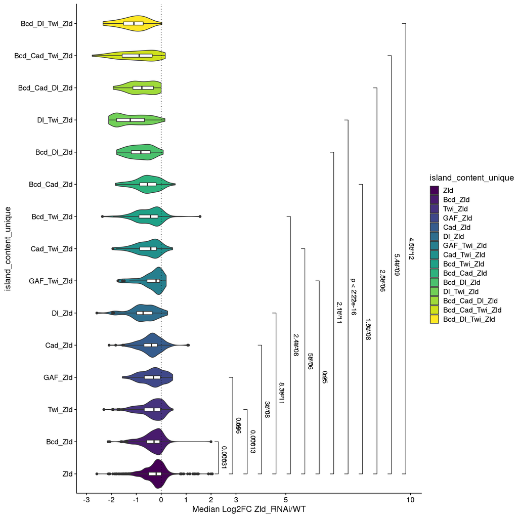

```r
box_order <- c("Zld", "Bcd_Zld", "Twi_Zld", "GAF_Zld","Cad_Zld", "Dl_Zld", "GAF_Twi_Zld", "Cad_Twi_Zld", "Bcd_Twi_Zld", "Bcd_Cad_Zld", "Bcd_Dl_Zld", "Dl_Twi_Zld", "Bcd_Cad_Dl_Zld", "Bcd_Cad_Twi_Zld", "Bcd_Dl_Twi_Zld")
zld_islands_w_de.df$island_content_unique <- factor(zld_islands_w_de.df$island_content_unique, levels = box_order)
my_comparisons <- list(c("Zld", "Bcd_Zld"), c("Zld", "GAF_Zld"),
                       c("Zld", "Twi_Zld"), c("Zld", "Cad_Zld"),
                       c("Zld", "Dl_Zld"), c("Zld", "Bcd_Twi_Zld"),
                       c("Zld", "Cad_Twi_Zld"), c("Zld", "GAF_Twi_Zld"),
                       c("Zld", "Bcd_Dl_Zld"), c("Zld", "Dl_Twi_Zld"),
                       c("Zld", "Bcd_Cad_Zld"), c("Zld", "Bcd_Cad_Dl_Zld"),
                       c("Zld", "Bcd_Cad_Twi_Zld"), c("Zld", "Bcd_Dl_Twi_Zld"))


islands_with_effect_violin.plot <- ggplot(zld_islands_w_de.df, aes(x=med_log2fc, y=island_content_unique)) +
  geom_violin(aes(fill=island_content_unique)) +
  geom_boxplot(width=.1)+
  stat_compare_means(comparisons = my_comparisons, method = "wilcox.test", label = "p.format", paired = FALSE)+
  stat_compare_means(comparisons = my_comparisons, method = "wilcox.test", label = "p.signif", paired = FALSE)+
  scale_x_continuous(name = "Median Log2FC Zld_RNAi/WT", breaks = c(-3, -2, -1, 0, 1, 2, 3, 5, 10))+
  geom_vline(xintercept = 0, linetype = 'dotted', color = 'black')+
  scale_fill_viridis_d()+
  theme_cowplot()
islands_with_effect_violin.plot
```

```r
ggsave("islands_with_effect_violin_signif.pdf", plot = islands_with_effect_violin.plot, path = "figures/13_island_analysis", height = 12, width = 20)
ggsave("islands_with_effect_violin_signif.png", plot = islands_with_effect_violin.plot, path = "figures/13_island_analysis", height = 12, width = 20)
```

# 8. Conclusions

Using island analysis, we can see that Zelda with patterning TF motifs generates the highest levels of chromatin accessibility over time, along with high H3K27ac and H3K4me1, and low nucleosome occupancy. Using zld- ATAC-seq data that we generated, we see that these Zelda and patterning TF islands are also most affected by the loss of Zelda, suggesting a hierarchy where upon loss of Zelda these regions lose the combined effects of Zelda pioneering and the effects of patterning TFs, which are dependent on Zelda, but do themselves increase chromatin accessibility in a more context-specific way.